summary — title: “Regularización de la regresión con glmnet” author: “Olivier Nuñez” date: “1 de abril de 2016” output: html_document —

### Preámbulo

#### Cuando se utiliza la regularización:

- Problema de predicción con una alto número de predictores (overfitting)
- Mucho ruido en la base de datos (muchos predictores no están relacionados con la respuesta)
- Alta correlación entre los predictores (multicolinealidad)

#### Porqué Regularizar?

- La estimación de los coeficientes puede ser muy inestable (altas varianzas)
- Permite una selección *continua* de variables
- Subsana los problemas que conlleva la multicolinealidad

#### En qué consiste la regularización?

**Regresión lineal**:

Para $i=1,2,\dots,N$,

$y_i = \beta_0 + \beta_1 x_{i1} + \beta_2 x_{i2} + \dots + \beta_K x_{iK} +\varepsilon_i$

donde $\varepsilon_i \sim N(0,\sigma^2)$.

los coeficientes $\beta_k$ se estiman sin restricción.

**Regresión con regulariazión**:

los coeficientes $\beta_k$ están restringido.

1. *Ridge regression*: $\sum_{k=1}^K \beta_k^2 \leq t$
2. *Lasso regression*: $\sum_{k=1}^K \left| \beta_k\right| \leq t$
3. *Elastic-net*: mixtura de Ridge y Lasso $\sum_{k=1}^K \left[ \alpha\left| \beta_k\right| + (1-\alpha) \beta_k^2 \right] \leq t$

#### Interpretación de la regularización:

- **Shrinkage**:
  - Ridge: asemeja los coeficientes de los predictores mutuamente correlacionados
  - Lasso: selecciona uno de estos predictores y descarta los demás.
- **PCA**: Penaliza las direcciones (combinaciones) de los predictores poco informativas.
- **Bayesian**:
  - Ridge ~ los coeficientes tienen una distribución (*a priori*) gaussiana.
  - Lasso ~ los coeficientes tienen una distribución (*a priori*) de Laplace.

### Quick tour por glmnet

```r
rm(list=ls()) #limpiamos la memoría
require(glmnet)

require(data.table)
require(ggplot2)
```

Un ejemplo de trenes sencillo para empezar

```r
######### Retrasos de trenes ###########
set.seed(4321) #fija la semilla para que el ejemplo sea reproducible.
n=1000 #tamaño de la muestra
DT=data.table(distancia=rnorm(n,500,100))
DT[,estaciones:= rpois(n,10)]
DT[,precio:=rnorm(n,50,10)]
DT=round(DT,2)
DT
```

```
##       distancia estaciones precio
##    1:    457.32         16  45.91
##    2:    477.64          8  57.78
##    3:    571.76         13  48.62
##    4:    584.14         10  59.13
##    5:    487.16          6  52.90
##   ---
##  996:    372.42          8  57.24
##  997:    371.15          9  52.84
##  998:    436.81          7  58.85
##  999:    633.80         11  34.71
## 1000:    258.98         10  40.82
```

Ahora generamos los retrasos

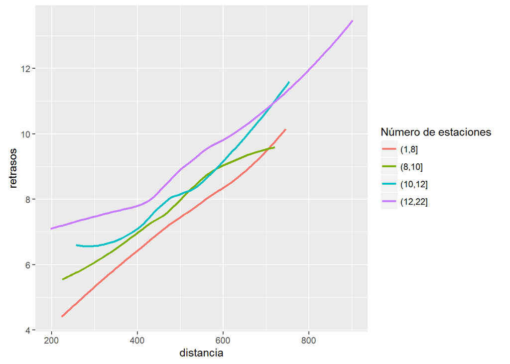

```r
DT[,retrasos:= 1 + distancia/100 + estaciones/5 + rnorm(n,0,1)]
ggplot(DT,aes(y=retrasos,x=distancia,color=cut(estaciones,quantile(estaciones),right=TRUE))) +
  geom_smooth(se=FALSE) + scale_color_discrete("Número de estaciones")
```

Resultado de una estimación lineal

```r
ols <- lm(retrasos ~ . ,DT)
summary(ols)
```

```
##
## Call:
## lm(formula = retrasos ~ ., data = DT)
##
## Residuals:
##     Min      1Q  Median      3Q     Max
## -3.2259 -0.6230  0.0089  0.6358  3.0901
##
## Coefficients:
##              Estimate Std. Error t value Pr(>|t|)
## (Intercept) 1.2131745  0.2470188   4.911 1.06e-06 ***
## distancia   0.0096490  0.0003088  31.248  < 2e-16 ***
## estaciones  0.1870312  0.0100462  18.617  < 2e-16 ***
## precio      0.0020255  0.0031895   0.635    0.526
## ---
## Signif. codes:  0 '***' 0.001 '**' 0.01 '*' 0.05 '.' 0.1 ' ' 1
##
## Residual standard error: 0.9704 on 996 degrees of freedom
## Multiple R-squared:  0.5681, Adjusted R-squared:  0.5668
## F-statistic: 436.6 on 3 and 996 DF,  p-value: < 2.2e-16
```

La estimación es bastante buena!

Pero, en realidad el precio está muy correlacionado con los demás predictores

```r
require(GGally)
```

```r
DT[,precio:=distancia/10 - estaciones + rnorm(n,0,.1)] #precio y distancia están correlados
#ggpairs(DT)
```

Ajustamos de nuevo una regresión lineal:

```r
ols <- lm(retrasos ~ . ,DT)
summary(ols)
```

```
##
## Call:
## lm(formula = retrasos ~ ., data = DT)
##
## Residuals:
##     Min      1Q  Median      3Q     Max
## -3.2243 -0.6226  0.0042  0.6238  3.0971
##
## Coefficients:
##             Estimate Std. Error t value Pr(>|t|)
## (Intercept)  1.31601    0.18772   7.010 4.38e-12 ***
## distancia    0.01297    0.03182   0.408    0.684
## estaciones   0.15342    0.31879   0.481    0.630
## precio      -0.03316    0.31824  -0.104    0.917
## ---
## Signif. codes:  0 '***' 0.001 '**' 0.01 '*' 0.05 '.' 0.1 ' ' 1
##
## Residual standard error: 0.9705 on 996 degrees of freedom
## Multiple R-squared:  0.5679, Adjusted R-squared:  0.5666
## F-statistic: 436.3 on 3 and 996 DF,  p-value: < 2.2e-16
```

Para solucionar este problema utilizamos una regresión de Lasso via glmnet:

```r
y=DT$retrasos
x=subset(DT,select=-retrasos)
x
```

```
##       distancia estaciones   precio
##    1:    457.32         16 29.68143
##    2:    477.64          8 40.01031
##    3:    571.76         13 44.14869
##    4:    584.14         10 48.53775
##    5:    487.16          6 42.80101
##   ---
##  996:    372.42          8 29.18446
##  997:    371.15          9 28.12897
##  998:    436.81          7 36.61226
##  999:    633.80         11 52.44815
## 1000:    258.98         10 15.91704
```

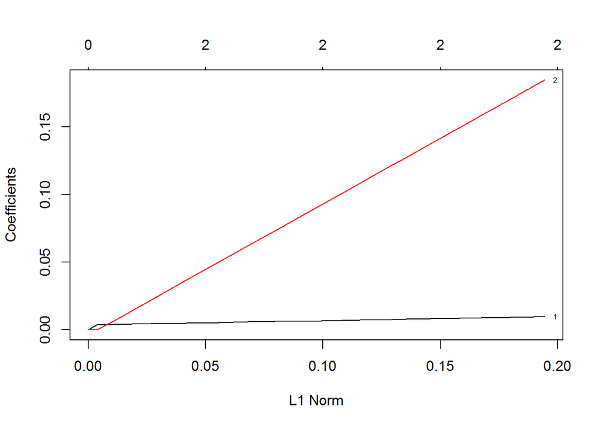

```r
lasso=glmnet(as.matrix(x),y)
plot(lasso,label=TRUE)
```

Para seleccionar el coeficiente de la penalización recurrimos a cross-validation:

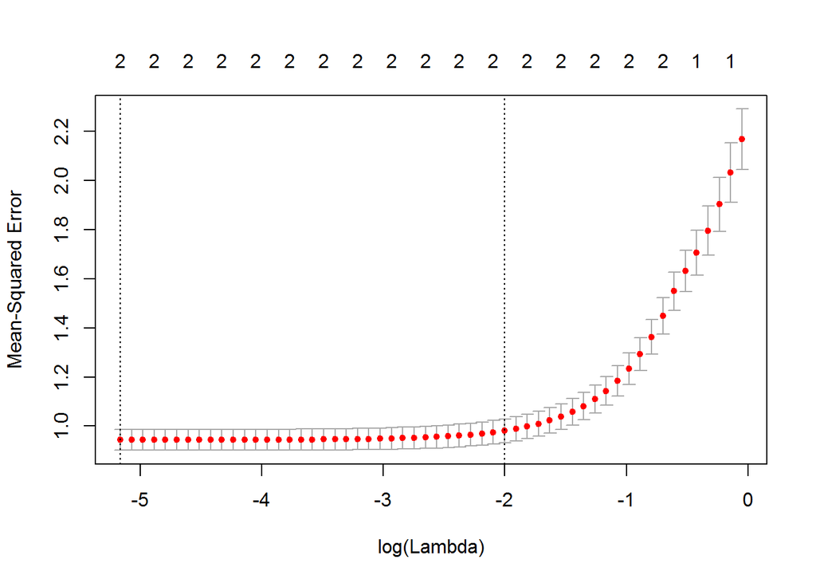

```r
cvlasso = cv.glmnet(as.matrix(x), y)
plot(cvlasso)
```

```r
coef(cvlasso, s = "lambda.min")
```

```
## 4 x 1 sparse Matrix of class "dgCMatrix"
##                       1
## (Intercept) 1.363234024
## distancia   0.009596977
## estaciones  0.184735707
## precio      .
```

Qué haría la regresión de Ridge?

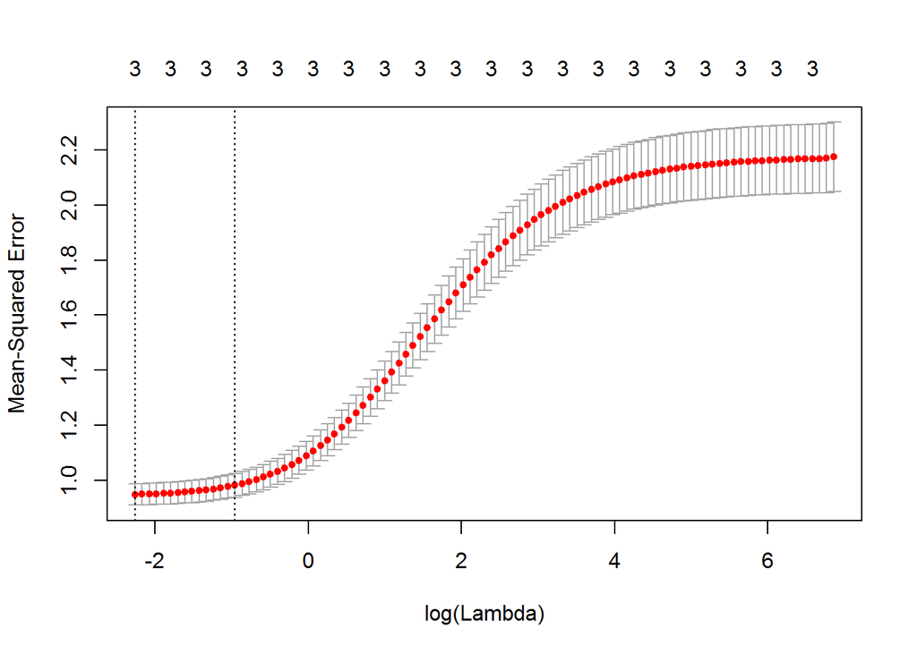

```r
cvridge = cv.glmnet(as.matrix(x), y,alpha=0)
plot(cvridge)
```

```r
coef(cvridge, s = "lambda.min")
```

```
## 4 x 1 sparse Matrix of class "dgCMatrix"
##                       1
## (Intercept) 1.670022805
## distancia   0.005803715
## estaciones  0.206200389
## precio      0.034372194
```

Y con la elastic-net

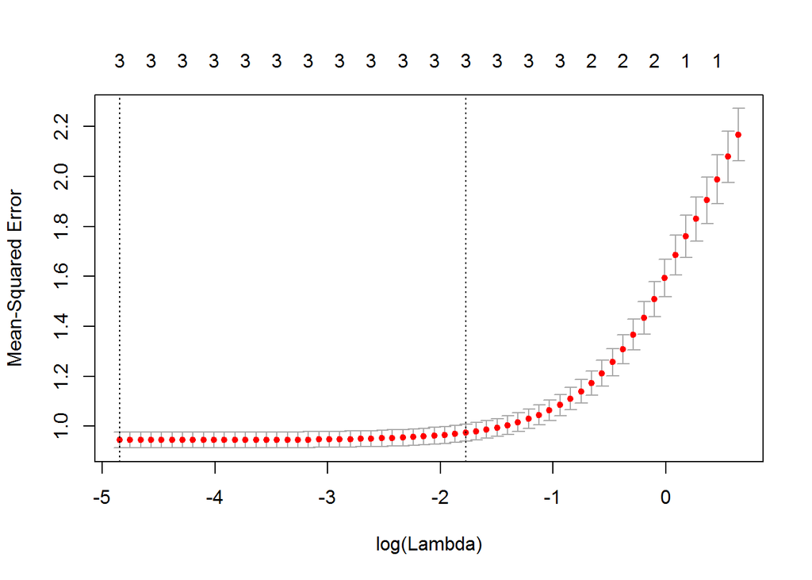

```r
cvnEN = cv.glmnet(as.matrix(x), y,alpha=.5)
plot(cvnEN)
```

```r
coef(cvnEN, s = "lambda.min")
```

```
## 4 x 1 sparse Matrix of class "dgCMatrix"
##                       1
## (Intercept) 1.364829073
## distancia   0.008572283
## estaciones  0.195003272
## precio      0.010201757
```

La multicolinealidad afecta la estimación de los coeficientes de la regresión, pero no tiene poque afectar la predición.

### Overfitting

Para ilustar este problema, seguimos con el ejemplo de los trenes.

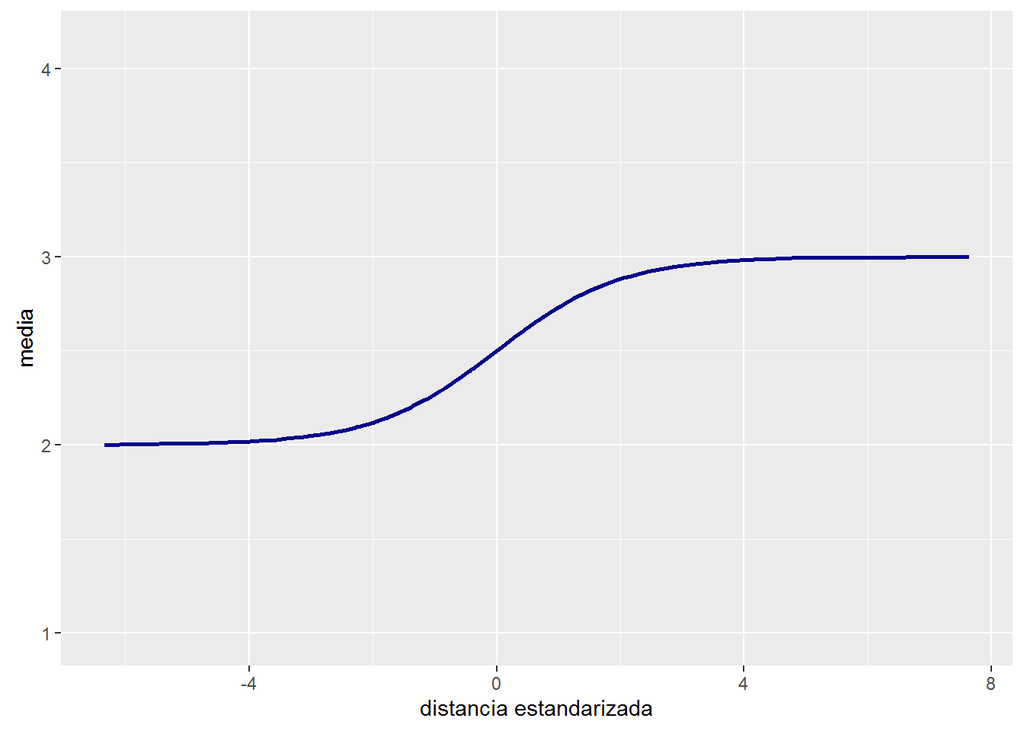

```r
n=100
DT=data.table(distancia=rnorm(n,0,3)) #distancias estandarizadas
DT[,media:= 2 + exp(distancia)/(1+exp(distancia))]
DT[,retrasos:= media + rnorm(n,0,.5)]
p<-ggplot(DT,aes(y=media,x=distancia)) + geom_line(size=1,color="blue4") +
  ylim(range(DT$retraso))+xlab("distancia estandarizada")
p
```

Para investigar la capacidad predictiva del modelo, partimos la base de datos en un conjunto de adiestrameinto y un conjunto de test:

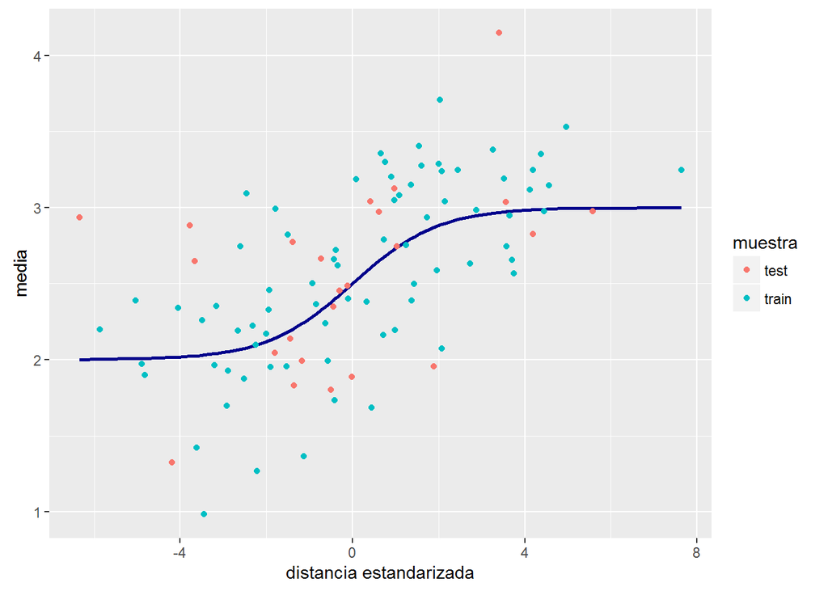

```r
DT[,muestra:=sample(c("train","test"),n,prob=c(2/3,1/3),replace=TRUE)]
p<- p + geom_point(aes(y=retrasos,color=muestra),DT)
p
```

Queremos ajustar una regresión polynomial

```r
poly=outer(DT$distancia,2:10,function(x,y) x^y)
DT=cbind(DT,poly=poly)
```

```r
ols <- lm(retrasos ~ . ,subset(DT,muestra=="train",select=-c(media,muestra)))
summary(ols)
```

```
##
## Call:
## lm(formula = retrasos ~ ., data = subset(DT, muestra == "train",
##     select = -c(media, muestra)))
##
## Residuals:
##      Min       1Q   Median       3Q      Max
## -0.95702 -0.27251  0.01975  0.25525  0.90672
##
## Coefficients:
##               Estimate Std. Error t value Pr(>|t|)
## (Intercept)  2.460e+00  1.262e-01  19.490   <2e-16 ***
## distancia    3.106e-01  1.365e-01   2.276   0.0262 *
## poly.V1      1.085e-01  1.149e-01   0.944   0.3485
## poly.V2     -4.264e-02  5.277e-02  -0.808   0.4220
## poly.V3     -2.024e-02  2.756e-02  -0.735   0.4653
## poly.V4      3.982e-03  6.171e-03   0.645   0.5210
## poly.V5      1.115e-03  2.440e-03   0.457   0.6492
## poly.V6     -1.516e-04  2.691e-04  -0.563   0.5751
## poly.V7     -1.947e-05  8.608e-05  -0.226   0.8217
## poly.V8      1.965e-06  3.923e-06   0.501   0.6182
## poly.V9      5.442e-08  1.004e-06   0.054   0.9569
## ---
## Signif. codes:  0 '***' 0.001 '**' 0.01 '*' 0.05 '.' 0.1 ' ' 1
##
## Residual standard error: 0.4514 on 65 degrees of freedom
## Multiple R-squared:  0.5017, Adjusted R-squared:  0.425
## F-statistic: 6.544 on 10 and 65 DF,  p-value: 6.584e-07
```

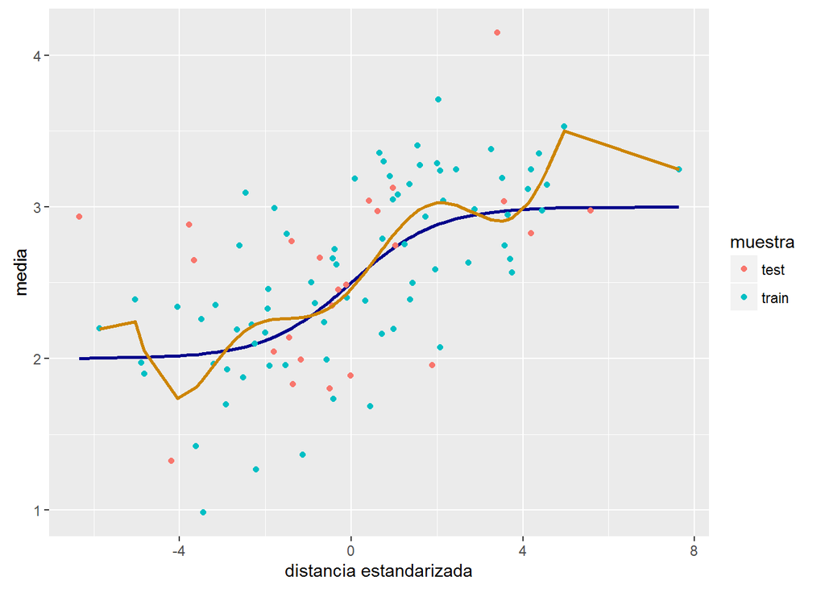

```r
DT[muestra=="train",fit.ols:=ols$fit] #overfitting !!
p<- p + geom_line(aes(x=distancia,y=fit.ols),data=subset(DT,muestra=="train"),col="orange3",size=1)
p
```

```r
pred=predict(ols,DT[muestra=="test",])
mse=mean((pred-DT[muestra=="test",retrasos])^2)
sprintf("MSE_ols = %.3f",mse)
```

```
## [1] "MSE_ols = 0.821"
```

Para regularizar esta regresión, utilizamos de nuevo glmnet

```r
DT[,fit:=NULL] #se borra el fit del ols
```

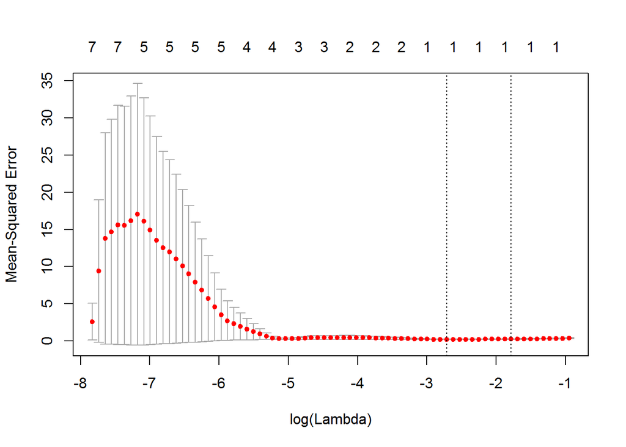

```r
x=subset(DT,muestra=="train",select=-c(retrasos,muestra,media,fit.ols))
y=subset(DT,muestra=="train")$retrasos
lasso = cv.glmnet(as.matrix(x), y)
plot(lasso)
```

```r
coef(lasso, s = "lambda.min")
```

```
## 11 x 1 sparse Matrix of class "dgCMatrix"
##                     1
## (Intercept) 2.5593030
## distancia   0.1159233
## poly.V1     .
## poly.V2     .
## poly.V3     .
## poly.V4     .
## poly.V5     .
## poly.V6     .
## poly.V7     .
## poly.V8     .
## poly.V9     .
```

Y predecimos

```r
fit.glmnet=predict(lasso,newx=as.matrix(x),s = "lambda.min")
x.new=subset(DT,muestra=="test",select=-c(retrasos,muestra,media,fit.ols))
pred=predict(lasso,newx=as.matrix(x.new),s = "lambda.min")
mse=mean((pred-DT[muestra=="test",retrasos])^2)
sprintf("MSE_glmnet = %.3f",mse)
```

```
## [1] "MSE_glmnet = 0.299"
```

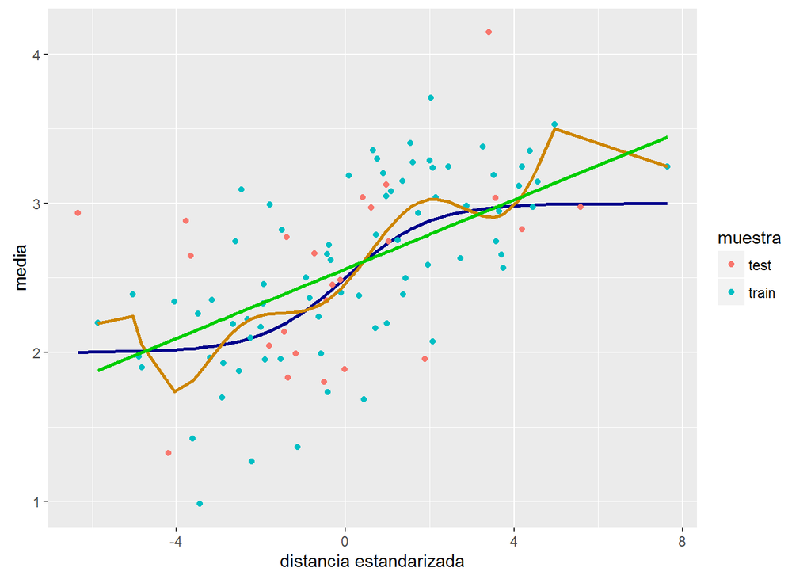

```r
DT[muestra=="train",fit.glmnet:=fit.glmnet]
p + geom_line(aes(x=distancia,y=fit.glmnet),data=subset(DT,muestra=="train"),col="green3",size=1)
```